# Info 201 students coding experience report

# Summary

In this report, we will investigate more about students’ experience from the survey data using two plots.

# plot 1: coding experience by class standing

This first plot shows the coding experience of different class standings, from which we see that Sophomore is the **largest** group of students in this class. For every class standing, the number of experienced programmers *(with lots or* *moderate coding experience)* is more than half of the total number. Hence it would not be very surprising if students generally do a great job in this class. Besides, we see that sophomore is also the **largest** group of students with no programming experience.

[interactive chart not shown]

# plot 2: git usage by coding experience

This second plot shows the git usage by coding experience.The **width** of each bar is proportional to the number of people with the corresponding coding experience. From this plot we see that most students have *never* used git before. Even more than half of people with *moderate* coding experience have *never* used git. Although *most* students with lots of programming experience have used git in the past, students at this coding experience level are only a *small* portion of the whole class.

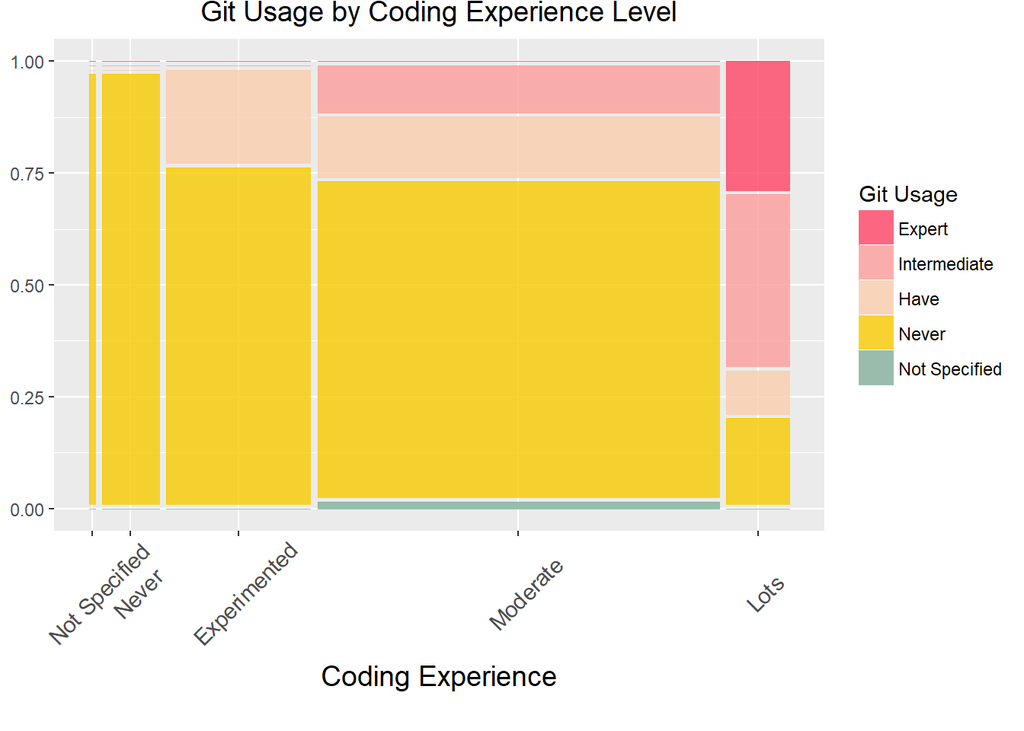